# Modelling Indigenous forests and landscape structure effects on fire-related diseases

# Data Loading and Preprocessing

Load temporal health data and coordinates, merge and clean the datasets

```r
incidence_data <- read.csv(here("data", "incidence_data.csv"), header = T)

fire_incidence_data <- incidence_data %>%
  dplyr::select(country, COD, year, IDH, X, Y, fire.incidence, for_PD, for_ED, for_AI,
                FS_PLAND, tot_IT, NOTackn_IT, acknlgd_IT, FS_noIT, pm25_SUM) %>%
  # Removing NAs from the dataset
  drop_na(fire.incidence)
```

# Data Overview and Distributions

## Summary statistics and structure for dataset

```r
(sk <- skim(fire_incidence_data))
```

Data summary

| Name | fire_incidence_data |
| --- | --- |
| Number of rows | 18158 |
| Number of columns | 16 |
| _______________________ |  |
| Column type frequency: |  |
| character | 2 |
| numeric | 14 |
| ________________________ |  |
| Group variables | None |

**Variable type: character**

| skim_variable | n_missing | complete_rate | min | max | empty | n_unique | whitespace |
| --- | --- | --- | --- | --- | --- | --- | --- |
| country | 0 | 1 | 4 | 8 | 0 | 6 | 0 |
| COD | 0 | 1 | 2 | 9 | 0 | 1147 | 0 |

**Variable type: numeric**

| skim_variable | n_missing | complete_rate | mean | sd | p0 | p25 | p50 | p75 | p100 | hist |
| --- | --- | --- | --- | --- | --- | --- | --- | --- | --- | --- |
| year | 0 | 1 | 2.011430e+03 | 4.990000e+00 | 2001.00 | 2008.00 | 2012.00 | 2.016000e+03 | 2.019000e+03 | ▃▅▆▇▇ |
| IDH | 0 | 1 | 7.200000e-01 | 4.000000e-02 | 0.63 | 0.69 | 0.72 | 7.600000e-01 | 7.800000e-01 | ▂▃▅▃▇ |
| X | 0 | 1 | -6.649776e+05 | 1.133722e+06 | -2172880.00 | -1712890.00 | -797646.50 | 3.336770e+05 | 1.740920e+06 | ▇▃▃▃▂ |
| Y | 0 | 1 | 2.729343e+06 | 7.059622e+05 | 1371160.00 | 2194820.00 | 2773930.00 | 3.209920e+06 | 4.274770e+06 | ▃▆▇▅▂ |
| fire.incidence | 0 | 1 | 7.896800e+03 | 1.418914e+04 | 0.00 | 487.51 | 2523.63 | 9.484740e+03 | 2.147040e+05 | ▇▁▁▁▁ |
| for_PD | 0 | 1 | 7.700000e-01 | 7.700000e-01 | 0.00 | 0.20 | 0.57 | 1.080000e+00 | 6.480000e+00 | ▇▂▁▁▁ |
| for_ED | 0 | 1 | 2.224000e+01 | 1.703000e+01 | 0.00 | 8.65 | 18.48 | 3.232000e+01 | 9.568000e+01 | ▇▅▂▁▁ |
| for_AI | 0 | 1 | 9.030000e+01 | 1.387000e+01 | 0.00 | 88.84 | 95.44 | 9.839000e+01 | 1.000000e+02 | ▁▁▁▁▇ |
| FS_PLAND | 0 | 1 | 5.462000e+01 | 3.143000e+01 | 0.00 | 27.23 | 56.58 | 8.533000e+01 | 9.981000e+01 | ▅▅▅▅▇ |
| tot_IT | 0 | 1 | 1.093000e+01 | 1.961000e+01 | 0.00 | 0.00 | 0.03 | 1.353000e+01 | 9.808000e+01 | ▇▁▁▁▁ |
| NOTackn_IT | 0 | 1 | 1.490000e+00 | 6.340000e+00 | 0.00 | 0.00 | 0.00 | 0.000000e+00 | 7.742000e+01 | ▇▁▁▁▁ |
| acknlgd_IT | 0 | 1 | 9.430000e+00 | 1.763000e+01 | 0.00 | 0.00 | 0.00 | 1.091000e+01 | 9.808000e+01 | ▇▁▁▁▁ |
| FS_noIT | 0 | 1 | 4.370000e+01 | 2.881000e+01 | 0.00 | 19.50 | 41.54 | 6.737000e+01 | 9.981000e+01 | ▇▇▆▅▅ |
| pm25_SUM | 0 | 1 | 8.552866e+10 | 1.960940e+11 | 16807229.50 | 2047033794.62 | 9398606639.25 | 5.360931e+10 | 1.926057e+12 | ▇▁▁▁▁ |

## Visualize the distribution of the response variables

### Log-transformation of fire-related diseases incidence

Log10 +1 aiming to reach normality

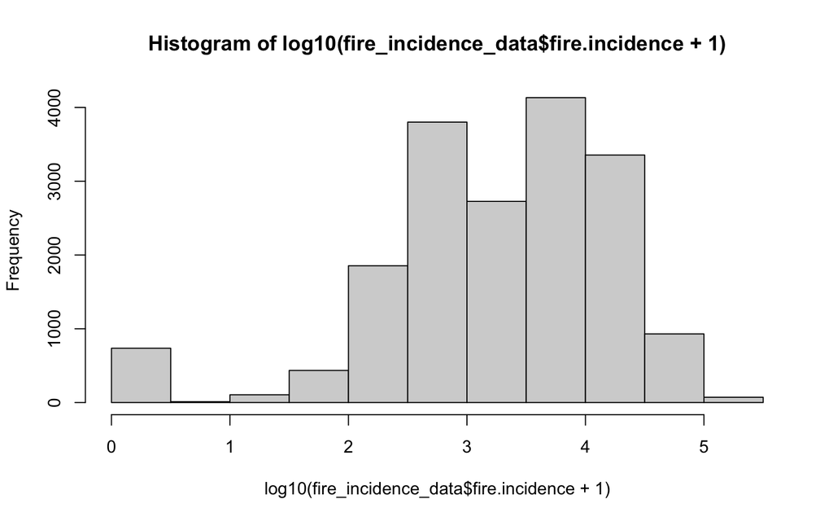

```r
hist(log10(fire_incidence_data$fire.incidence + 1))
```

# Modelling

## Absence of effect (aka Baseline Model, ‘null’)

Fit a model of absence of effect with only an intercept and random effects for year and spatial coordinates. This model serves as a baseline to compare against models with predictors.

```r
mfire0 <- gam(log10(fire.incidence+1) ~ 1 +
                offset(IDH) + s(year, bs = "re") + s(X, Y),
                data = fire_incidence_data)
# summary(mfire0) ; AIC(mfire0)
```

## Single-Predictor Models

```r
# Model for forest cover within the entire COD/municipality (FS_PLAND)
# Linear model for FS_PLAND
mfire_FS <- gam(log10(fire.incidence+1) ~ scale(FS_PLAND) + offset(IDH) + s(year, bs = "re") + s(X, Y),
                data = fire_incidence_data)

# Polynomial model (second degree) for tot_IT
mfire_IT2 <- gam(log10(fire.incidence+1) ~ poly(scale(tot_IT), 2) +
                   offset(IDH) + s(year, bs = "re") + s(X, Y),
                data = fire_incidence_data)
# AICtab(mfire_IT2, mfire_IT)

# Model for forest edge density (for_ED)
mfire_ED <- gam(log10(fire.incidence+1) ~ scale(for_ED) +
                    offset(IDH) +  s(year, bs = "re") + s(X, Y),
                data = fire_incidence_data)

# Model for patch density (for_PD)
mfire_PD <- gam(log10(fire.incidence+1) ~ scale(for_PD) +
                    offset(IDH) +  s(year, bs = "re") + s(X, Y),
                data = fire_incidence_data)
```

## Double additive Models I: indigenous territories and forest cover outside IT

Build additive models combining Indigenous Territories (tot_IT) and forest cover outside Indigenous Territories (FS_noIT)

```r
# Additive model with polynomial terms for tot_IT and FS_noIT
mfire_ITFSno <- gam(log10(fire.incidence+1) ~ poly(scale(tot_IT), 2) + poly(scale(FS_noIT), 2) +
                      offset(IDH) +  s(year, bs = "re") + s(X, Y),
                data = fire_incidence_data)
# summary(mfire_ITFSno); AIC(mfire_ITFSno)  # Display summary and AIC for the model
```

### Double additive models II: overall forest cover and fragmentation

Build models combining overall forest cover (FS_PLAND) and fragmentation (for_ED and for_PD)

```r
# Additive model combining FS_PLAND and for_ED
mfire_FSED <- gam(log10(fire.incidence+1) ~ scale(FS_PLAND) + scale(for_ED) +
                       offset(IDH) + s(year, bs = "re") + s(X, Y),
                data = fire_incidence_data)
# summary(mfire_FSED); AIC(mfire_FSED)  # Display summary and AIC for the model

# Additive model combining FS_PLAND and for_PD
mfire_FSPD <- gam(log10(fire.incidence+1) ~ scale(FS_PLAND) + scale(for_PD) +
                       offset(IDH) + s(year, bs = "re") + s(X, Y),
                data = fire_incidence_data)
# summary(mfire_FSPD); AIC(mfire_FSPD)  # Display summary and AIC for the model
```

### Double additive models III: indigenous territories and fragmentation

```r
mfire_TIED <- gam(log10(fire.incidence+1) ~ poly(scale(tot_IT),2) + scale(for_ED) +
                  offset(IDH) +  s(year, bs = "re") + s(X, Y),
                data = fire_incidence_data)
# summary(mfire_TIED); AIC(mfire_TIED)

mfire_TIPD <- gam(log10(fire.incidence+1) ~ poly(scale(tot_IT),2) + scale(for_PD) +
                  offset(IDH) +  s(year, bs = "re") + s(X, Y),
                data = fire_incidence_data)
# summary(mfire_TIPD); AIC(mfire_TIPD)
```

### Tripple additives: indigenous territories + forest cover outside IT + fragmentation

```r
mfire_ITFSED <- gam(log10(fire.incidence+1) ~ poly(scale(tot_IT),2) +
                         poly(scale(FS_noIT),2) + scale(for_ED) +
                         offset(IDH) +  s(year, bs = "re") + s(X, Y),
                data = fire_incidence_data)
# summary(mfire_ITFSED); AIC(mfire_ITFSED)

mfire_ITFSPD <- gam(log10(fire.incidence+1) ~ poly(scale(tot_IT),2) +
                         poly(scale(FS_noIT),2) + scale(for_PD) +
                         offset(IDH) +  s(year, bs = "re") + s(X, Y),
                data = fire_incidence_data)
# summary(mfire_ITFSPD); AIC(mfire_ITFSPD)
```

## Interactive Models I: indigenous territories * forest cover outside IT

```r
# interativos IT * forest (FS_noIT)
mfire_ITFSno1i <- gam(log10(fire.incidence+1) ~ poly(scale(tot_IT),2) * scale(FS_noIT) +
                      offset(IDH) +  s(year, bs = "re") + s(X, Y),
                data = fire_incidence_data)
# summary(mfire_ITFSno1i); AIC(mfire_ITFSno1i)

mfire_IT1FSnoi <- gam(log10(fire.incidence+1) ~ scale(tot_IT) * poly(scale(FS_noIT, 2)) +
                       offset(IDH) +  s(year, bs = "re") + s(X, Y),
                data = fire_incidence_data)
# summary(mfire_IT1FSnoi); AIC(mfire_IT1FSnoi)
```

### Interactive Models II: overall forest cover * fragmentation

```r
## interactive landscape structure
mfire_FSEDi <- gam(log10(fire.incidence+1) ~
                     poly(scale(FS_PLAND),2) * scale(for_ED) +
                       offset(IDH) +  s(year, bs = "re") + s(X, Y),
                data = fire_incidence_data)
# summary(mfire_FSEDi); AIC(mfire_FSEDi)

mfire_FSPDi <- gam(log10(fire.incidence+1) ~
                        poly(scale(FS_PLAND),2) * scale(for_PD) +
                       offset(IDH) +  s(year, bs = "re") + s(X, Y),
                data = fire_incidence_data)
# summary(mfire_FSPDi); AIC(mfire_FSPDi)
```

## Interactive Models III: indigenous territories * fragmentation

```r
mfire_TIEDi <- gam(log10(fire.incidence+1) ~ poly(scale(tot_IT),2) * scale(for_ED) +
                    offset(IDH) +  s(year, bs = "re") + s(X, Y),
                data = fire_incidence_data)
# summary(mfire_TIEDi); AIC(mfire_TIEDi)

mfire_TIPDi <- gam(log10(fire.incidence+1) ~  poly(scale(tot_IT),2) * scale(for_PD) +
                    offset(IDH) + s(year, bs = "re") + s(X, Y),
                data = fire_incidence_data)
# summary(mfire_TIPDi); AIC(mfire_TIPDi)
```

### Additive and interative model but keeping interaction with only two varibles:

#### indigenous territories + ( forest cover outside IT * fragmentation )

```r
mfire_ITiFSED <- gam(log10(fire.incidence+1) ~ poly(scale(tot_IT),2) + poly(scale(FS_noIT),2) * scale(for_ED) +
                      offset(IDH) +  s(year, bs = "re") + s(X, Y),
                data = fire_incidence_data)
# summary(mfire_ITiFSED); AIC(mfire_ITiFSED)

mfire_ITiFSPD <- gam(log10(fire.incidence+1) ~ poly(scale(tot_IT),2) + poly(scale(FS_noIT),2) * scale(for_PD) +
                      offset(IDH) +  s(year, bs = "re") + s(X, Y),
                data = fire_incidence_data)
# summary(mfire_ITiFSPD); AIC(mfire_ITiFSPD)
```

#### forest cover outside IT + ( indigenous territories * fragmentation )

```r
mfire_FSiTIED <- gam(log10(fire.incidence+1) ~ poly(scale(FS_noIT),2) +
                       poly(scale(tot_IT),2) * scale(for_ED) +
                       offset(IDH) +  s(year, bs = "re") + s(X, Y),
                data = fire_incidence_data)
# summary(mfire_FSiTIED); AIC(mfire_FSiTIED)

mfire_FSiTIPD <- gam(log10(fire.incidence+1) ~ poly(scale(FS_noIT),2) +
                       poly(scale(tot_IT),2) * scale(for_PD) +
                       offset(IDH) + s(year, bs = "re") + s(X, Y),
                data = fire_incidence_data)
# summary(mfire_FSiTIPD); AIC(mfire_FSiTIPD)
```

#### fragmentation + ( indigenous territories * forest cover outside IT )

```r
mfire_EDiFSTI1 <- gam(log10(fire.incidence+1) ~ poly(scale(FS_noIT),2) * scale(tot_IT) + scale(for_ED) +
                       offset(IDH) +  s(year, bs = "re") + s(X, Y),
                data = fire_incidence_data)
# summary(mfire_EDiFSTI1); AIC(mfire_EDiFSTI1)

mfire_EDiFS1TI <- gam(log10(fire.incidence+1) ~ scale(FS_noIT) * poly(scale(tot_IT),2) + scale(for_ED) +
                       offset(IDH) +  s(year, bs = "re") + s(X, Y),
                data = fire_incidence_data)
# summary(mfire_EDiFS1TI); AIC(mfire_EDiFS1TI)

mfire_PDiFSTI1 <- gam(log10(fire.incidence+1) ~ poly(scale(FS_noIT),2) * scale(tot_IT) + scale(for_PD) +
                       offset(IDH) + s(year, bs = "re") + s(X, Y),
                data = fire_incidence_data)
# summary(mfire_PDiFSTI1); AIC(mfire_PDiFSTI1)

mfire_PDiFS1TI <- gam(log10(fire.incidence+1) ~ scale(FS_noIT) * poly(scale(tot_IT),2) + scale(for_PD) +
                       offset(IDH) + s(year, bs = "re") + s(X, Y),
                data = fire_incidence_data)
# summary(mfire_PDiFS1TI); AIC(mfire_PDiFS1TI)
```

# Model Selection Using AIC Comparison

Perform model selection by comparing all models based on AIC using AICtab function

```r
(mod.sel <- AICtab(
              # Absence of effect (aka Baseline Model, 'null')
              mfire0,
              # Single-Predictor Models
              mfire_FS,
              mfire_IT2,
              mfire_ED,
              mfire_PD,
              # Double additive Models I: indigenous territories and forest cover outside IT
              mfire_ITFSno,
              # Double additive models II: overall forest cover and fragmentation
              mfire_FSED,
              mfire_FSPD,
              # Double additive models III: indigenous territories and fragmentation
              mfire_TIED,
              mfire_TIPD,
              # Tripple additives: indigenous territories + forest cover outside IT + fragmentation
              mfire_ITFSED,
              mfire_ITFSPD,
              ## Interactive Models I: indigenous territories * forest cover outside IT
              mfire_ITFSno1i,
              mfire_IT1FSnoi,
              # Interactive Models II: overall forest cover * fragmentation
              mfire_FSEDi,
              mfire_FSPDi,
              # Interactive Models III: indigenous territories * fragmentation
              mfire_TIEDi,
              mfire_TIPDi,
              # Additive and interative model but keeping interaction with only two varibles:
              # indigenous territories + ( forest cover outside IT * fragmentation )
              mfire_ITiFSED,
              mfire_ITiFSPD,
              # forest cover outside IT + ( indigenous territories * fragmentation )
              mfire_FSiTIED,
              mfire_FSiTIPD,
              # fragmentation + ( indigenous territories * forest cover outside IT )
              mfire_EDiFSTI1,
              mfire_EDiFS1TI,
              mfire_PDiFSTI1,
              mfire_PDiFS1TI,
       base = TRUE, weights = TRUE))  # Include null model and calculate weights
```

```
##                AIC     dAIC    df   weight
## mfire_EDiFSTI1 33282.6     0.0 36.9 1
## mfire_PDiFSTI1 33334.1    51.5 36.9 <0.001
## mfire_ITiFSED  33339.3    56.7 37.9 <0.001
## mfire_FSiTIED  33377.3    94.7 37.9 <0.001
## mfire_ITiFSPD  33379.6    97.0 37.9 <0.001
## mfire_TIEDi    33382.7   100.1 35.9 <0.001
## mfire_PDiFS1TI 33385.2   102.5 36.9 <0.001
## mfire_EDiFS1TI 33388.2   105.5 36.9 <0.001
## mfire_FSiTIPD  33395.2   112.5 37.9 <0.001
## mfire_FSPDi    33396.9   114.3 35.9 <0.001
## mfire_ITFSED   33397.8   115.1 35.9 <0.001
## mfire_ITFSPD   33400.2   117.6 35.9 <0.001
## mfire_TIPDi    33407.5   124.9 35.9 <0.001
## mfire_TIED     33415.5   132.9 33.9 <0.001
## mfire_FSEDi    33415.9   133.3 35.9 <0.001
## mfire_TIPD     33417.1   134.5 33.9 <0.001
## mfire_FSPD     33455.8   173.1 32.9 <0.001
## mfire_ED       33469.5   186.8 31.9 <0.001
## mfire_FSED     33471.6   188.9 32.9 <0.001
## mfire_PD       33490.6   208.0 31.9 <0.001
## mfire_ITFSno1i 33520.2   237.5 35.9 <0.001
## mfire_IT2      33532.3   249.7 32.9 <0.001
## mfire_ITFSno   33533.0   250.4 34.9 <0.001
## mfire_IT1FSnoi 33553.8   271.1 33.9 <0.001
## mfire0         33586.7   304.1 30.9 <0.001
## mfire_FS       33588.2   305.6 31.9 <0.001
```

# Top selected model output

Summarize the selected model to examine the fitted results

```r
summary(mfire_EDiFSTI1)
```

```
##
## Family: gaussian
## Link function: identity
##
## Formula:
## log10(fire.incidence + 1) ~ poly(scale(FS_noIT), 2) * scale(tot_IT) +
##     scale(for_ED) + offset(IDH) + s(year, bs = "re") + s(X, Y)
##
## Parametric coefficients:
##                                         Estimate Std. Error t value Pr(>|t|)
## (Intercept)                             6.907195   0.634149  10.892  < 2e-16
## poly(scale(FS_noIT), 2)1                0.314229   1.161075   0.271 0.786674
## poly(scale(FS_noIT), 2)2                4.177709   1.075695   3.884 0.000103
## scale(tot_IT)                           0.029833   0.012314   2.423 0.015417
## scale(for_ED)                           0.105821   0.007203  14.692  < 2e-16
## poly(scale(FS_noIT), 2)1:scale(tot_IT)  2.687523   1.747111   1.538 0.124001
## poly(scale(FS_noIT), 2)2:scale(tot_IT) -9.713782   1.179222  -8.237  < 2e-16
##
## (Intercept)                            ***
## poly(scale(FS_noIT), 2)1
## poly(scale(FS_noIT), 2)2               ***
## scale(tot_IT)                          *
## scale(for_ED)                          ***
## poly(scale(FS_noIT), 2)1:scale(tot_IT)
## poly(scale(FS_noIT), 2)2:scale(tot_IT) ***
## ---
## Signif. codes:  0 '***' 0.001 '**' 0.01 '*' 0.05 '.' 0.1 ' ' 1
##
## Approximate significance of smooth terms:
##             edf Ref.df   F p-value
## s(year)  0.1107      1  48  <2e-16 ***
## s(X,Y)  28.7719     29 926  <2e-16 ***
## ---
## Signif. codes:  0 '***' 0.001 '**' 0.01 '*' 0.05 '.' 0.1 ' ' 1
##
## R-sq.(adj) =  0.638   Deviance explained = 64.2%
## GCV = 0.36603  Scale est. = 0.36531   n = 18158
```

Tidy up the model summary to get a clean output of the parametric terms

```r
tidy(mfire_EDiFSTI1, parametric = TRUE)
```

```
## # A tibble: 7 × 5
##   term                                   estimate std.error statistic  p.value
##   <chr>                                     <dbl>     <dbl>     <dbl>    <dbl>
## 1 (Intercept)                              6.91     0.634      10.9   1.53e-27
## 2 poly(scale(FS_noIT), 2)1                 0.314    1.16        0.271 7.87e- 1
## 3 poly(scale(FS_noIT), 2)2                 4.18     1.08        3.88  1.03e- 4
## 4 scale(tot_IT)                            0.0298   0.0123      2.42  1.54e- 2
## 5 scale(for_ED)                            0.106    0.00720    14.7   1.39e-48
## 6 poly(scale(FS_noIT), 2)1:scale(tot_IT)   2.69     1.75        1.54  1.24e- 1
## 7 poly(scale(FS_noIT), 2)2:scale(tot_IT)  -9.71     1.18       -8.24  1.88e-16
```

# Model Diagnostics

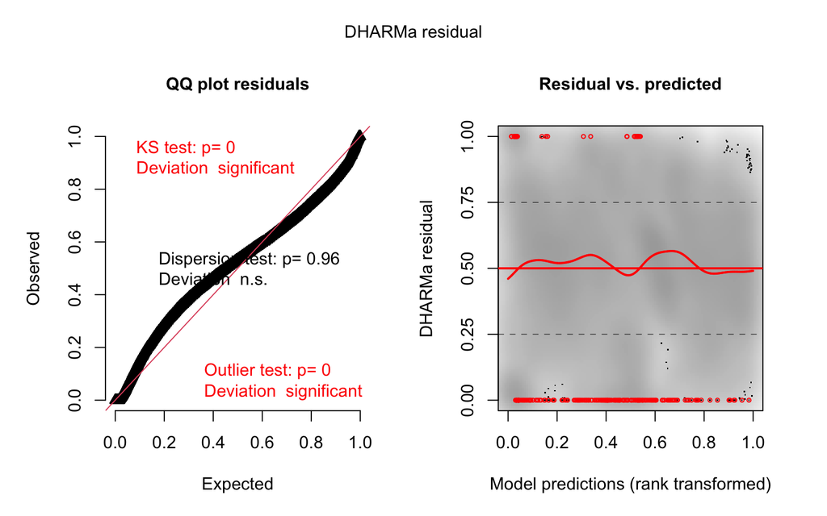

```r
resid <- simulateResiduals(mfire_EDiFSTI1)
plot(resid)
```

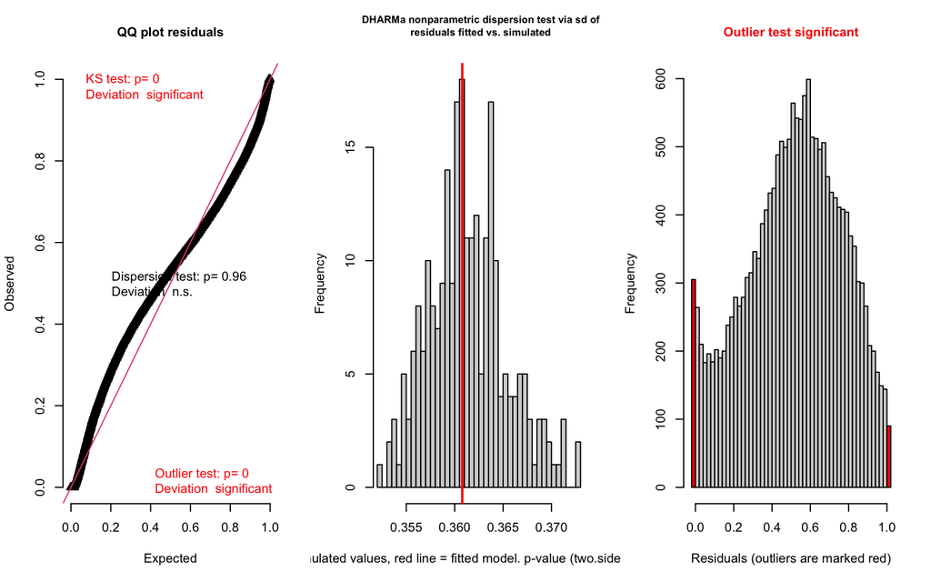

```
## $uniformity
##
##  Asymptotic one-sample Kolmogorov-Smirnov test
##
## data:  simulationOutput$scaledResiduals
## D = 0.093457, p-value < 2.2e-16
## alternative hypothesis: two-sided
##
##
## $dispersion
##
##  DHARMa nonparametric dispersion test via sd of residuals fitted vs.
##  simulated
##
## data:  simulationOutput
## dispersion = 0.99844, p-value = 0.96
## alternative hypothesis: two.sided
##
##
## $outliers
##
##  DHARMa outlier test based on exact binomial test with approximate
##  expectations
##
## data:  simulationOutput
## outliers at both margin(s) = 395, observations = 18158, p-value <
## 2.2e-16
## alternative hypothesis: true probability of success is not equal to 0.007968127
## 95 percent confidence interval:
##  0.01968103 0.02398102
## sample estimates:
## frequency of outliers (expected: 0.00796812749003984 )
##                                              0.0217535
```

```
## $uniformity
##
##  Asymptotic one-sample Kolmogorov-Smirnov test
##
## data:  simulationOutput$scaledResiduals
## D = 0.093457, p-value < 2.2e-16
## alternative hypothesis: two-sided
##
##
## $dispersion
##
##  DHARMa nonparametric dispersion test via sd of residuals fitted vs.
##  simulated
##
## data:  simulationOutput
## dispersion = 0.99844, p-value = 0.96
## alternative hypothesis: two.sided
##
##
## $outliers
##
##  DHARMa outlier test based on exact binomial test with approximate
##  expectations
##
## data:  simulationOutput
## outliers at both margin(s) = 395, observations = 18158, p-value <
## 2.2e-16
## alternative hypothesis: true probability of success is not equal to 0.007968127
## 95 percent confidence interval:
##  0.01968103 0.02398102
## sample estimates:
## frequency of outliers (expected: 0.00796812749003984 )
##                                              0.0217535
```

```r
testResiduals(resid, plot = TRUE)
```

Look at selected predictors:

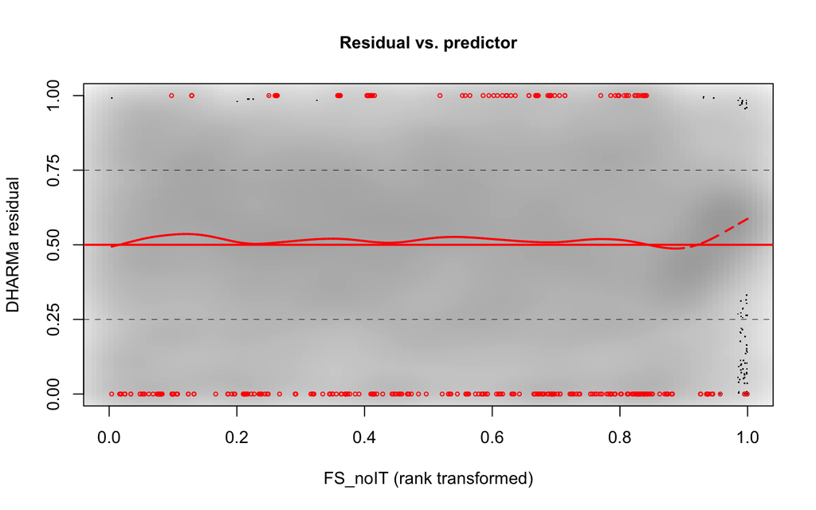

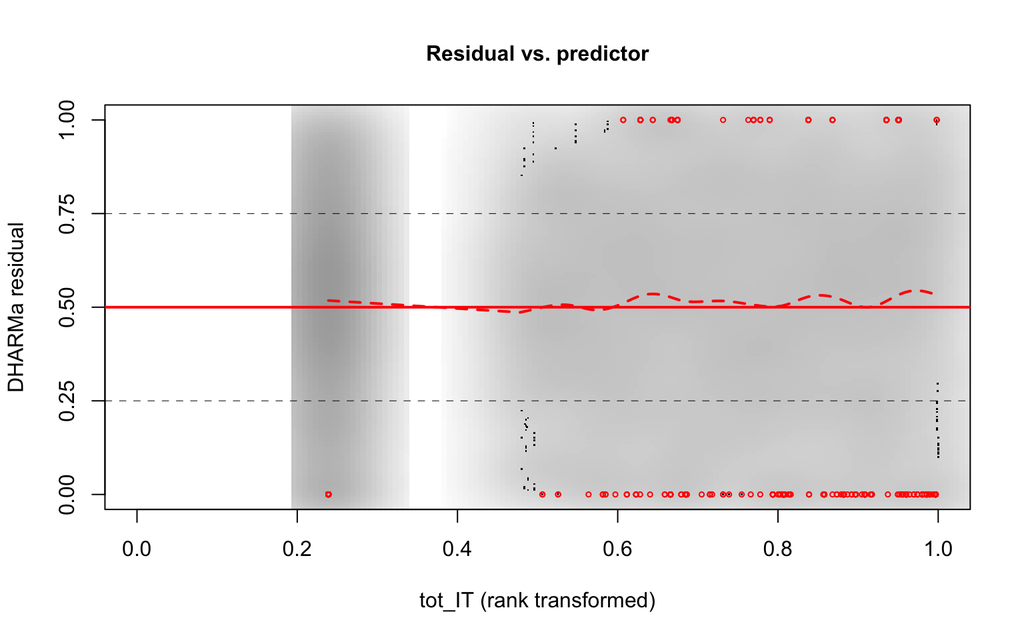

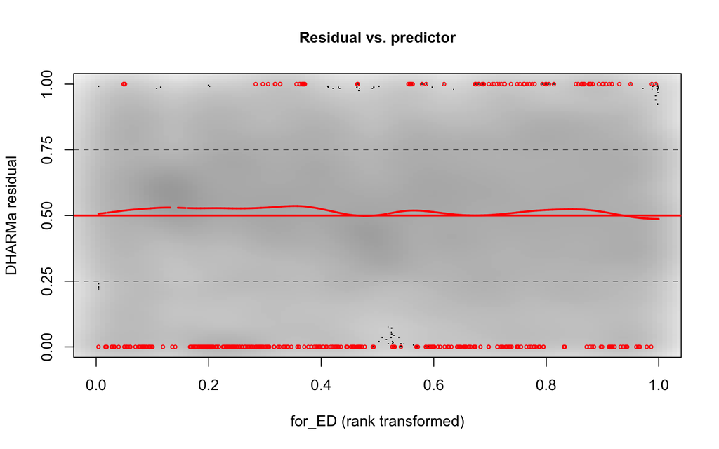

```r
plotResiduals(resid, fire_incidence_data$FS_noIT); plotResiduals(resid, fire_incidence_data$tot_IT); plotResiduals(resid, fire_incidence_data$for_ED)
```

# Prediction plot

We originally use orthogonal polynomials (i.e. ‘poly(predictor_variable, 2)’) for model selection due to their statistical advantages, which often leads to more reliable statistical inference. So model selection was based on orthogonal polynomials (`poly(x, 2)`) for robustness, but for practical visualization purpose, we use regular quadratic terms (`I(x^2)`) for clarity. The overall predicted trends (i.e., the shapes of the response curves) produced by a model using orthogonal polynomials (`poly(x, 2)`) and regular quadratic terms (`I(x^2)`) are exactly the same. Both models capture the quadratic relationships in the data.

```r
mfire_EDiFSTI1_quad <- gam(log10(fire.incidence + 1) ~ scale(for_ED) +
                            scale(FS_noIT) * scale(tot_IT) + I(scale(FS_noIT)^2) * scale(tot_IT) +
                             offset(IDH) + s(year, bs = "re") + s(X, Y),
                          data = fire_incidence_data)

summary(mfire_EDiFSTI1_quad)
```

```
##
## Family: gaussian
## Link function: identity
##
## Formula:
## log10(fire.incidence + 1) ~ scale(for_ED) + scale(FS_noIT) *
##     scale(tot_IT) + I(scale(FS_noIT)^2) * scale(tot_IT) + offset(IDH) +
##     s(year, bs = "re") + s(X, Y)
##
## Parametric coefficients:
##                                    Estimate Std. Error t value Pr(>|t|)
## (Intercept)                        6.873698   0.634215  10.838  < 2e-16 ***
## scale(for_ED)                      0.105821   0.007203  14.692  < 2e-16 ***
## scale(FS_noIT)                    -0.003929   0.008037  -0.489 0.624953
## scale(tot_IT)                      0.107719   0.009722  11.080  < 2e-16 ***
## I(scale(FS_noIT)^2)                0.033499   0.008625   3.884 0.000103 ***
## scale(FS_noIT):scale(tot_IT)       0.034503   0.011739   2.939 0.003296 **
## scale(tot_IT):I(scale(FS_noIT)^2) -0.077890   0.009456  -8.237  < 2e-16 ***
## ---
## Signif. codes:  0 '***' 0.001 '**' 0.01 '*' 0.05 '.' 0.1 ' ' 1
##
## Approximate significance of smooth terms:
##             edf Ref.df   F p-value
## s(year)  0.1107      1  48  <2e-16 ***
## s(X,Y)  28.7719     29 926  <2e-16 ***
## ---
## Signif. codes:  0 '***' 0.001 '**' 0.01 '*' 0.05 '.' 0.1 ' ' 1
##
## R-sq.(adj) =  0.638   Deviance explained = 64.2%
## GCV = 0.36603  Scale est. = 0.36531   n = 18158
```

Plot with new_data:

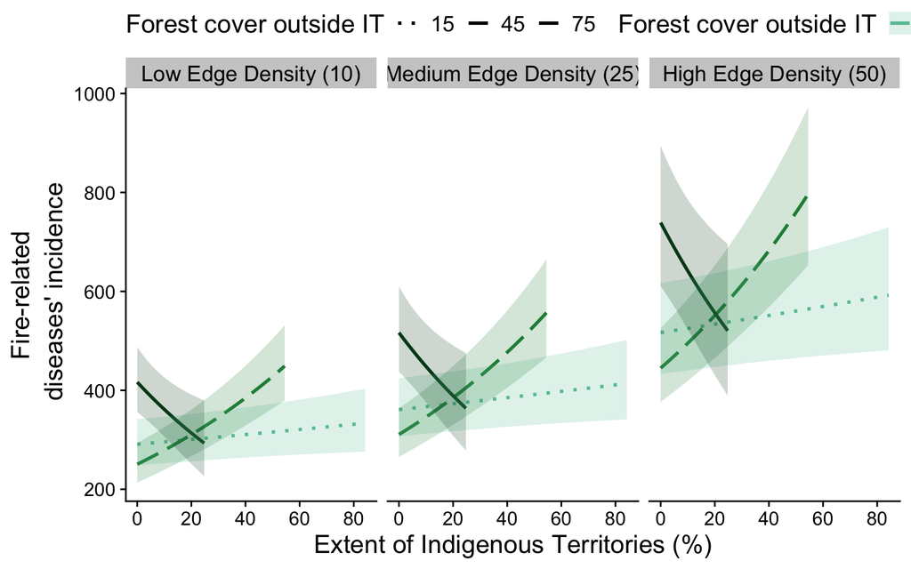

```r
# Define three levels of Forest Cover Outside IT (FS_noIT) and Edge Density (for_ED)
new_data <- expand.grid(
  tot_IT = seq(min(fire_incidence_data$tot_IT, na.rm = TRUE), max(fire_incidence_data$tot_IT, na.rm = TRUE), length.out = 100),
  for_ED = c(10, 25, 50),  # Three fixed levels of Edge Density
  FS_noIT = c(15, 45, 75),  # Three levels of Forest Cover Outside IT
  IDH = median(fire_incidence_data$IDH, na.rm = TRUE),
  year = median(fire_incidence_data$year, na.rm = TRUE),
  X = median(fire_incidence_data$X, na.rm = TRUE),
  Y = median(fire_incidence_data$Y, na.rm = TRUE)
)

# Adjust the filtering based on the specific rules for tot_IT and FS_noIT
new_data <- new_data %>%
  filter((FS_noIT == 15 & tot_IT <= 85) |
         (FS_noIT == 45 & tot_IT <= 55) |
         (FS_noIT == 75 & tot_IT <= 25))

# Now generate the predictions after filtering
predictions <- predict(mfire_EDiFSTI1_quad, newdata = new_data, type = "response", se.fit = TRUE)

# Back-transforming predictions
new_data$predicted <- 10^predictions$fit - 1
new_data$conf.low <- 10^(predictions$fit - 1.96 * predictions$se.fit) - 1
new_data$conf.high <- 10^(predictions$fit + 1.96 * predictions$se.fit) - 1

# Plot with tot_IT on the x-axis and facets for different levels of FS_noIT
(fire <- ggplot(new_data, aes(x = tot_IT, y = predicted,
                              linetype = as.factor(FS_noIT), color = as.factor(FS_noIT))) +
  geom_line(linewidth = 1) +
  geom_ribbon(aes(ymin = conf.low, ymax = conf.high, fill = as.factor(FS_noIT)),
              linetype= 0, alpha = 0.2) +
  labs(
    x = "Extent of Indigenous Territories (%)",
    y = "Fire-related\n diseases' incidence",
    color = "Forest cover outside IT",
    fill = "Forest cover outside IT",
    linetype = "Forest cover outside IT"
  ) +
  theme(legend.position = "top",
              text = element_text(size = 16),
        axis.title.y = element_text(size = 16, lineheight = 1.1),
        axis.title.x = element_text(size = 16)) +
  scale_color_manual(values = c("#66c2a4", "#238b45", "#00441b"), labels = c("15%", "45%", "75%")) +
  scale_fill_manual(values = c("#66c2a4", "#238b45", "#00441b"), labels = c("15%", "45%", "75%")) +
    scale_linetype_manual(values = c("dotted", "longdash", "solid")) +
  facet_wrap(~ for_ED, labeller = as_labeller(c("10" = "Low Edge Density (10)",
                                                "25" = "Medium Edge Density (25)",
                                                "50" = "High Edge Density (50)"))))
```

```r
# Save the plot
ggsave(here("outputs", "figures", "fire_topmodel_filtered.png"), width = 9, height = 4)
```